[figure not shown]

高龄程序猿自救指北

[figure not shown]

# 但行

## ActionScript

> 1999

Flash ->

## PHP

> 2000

ASP ->

## NucleusCMS

> 2002

Blogging

## CZUG

> 2003~07

Plone

[figure not shown]

2004-0930-effeBDragon

## 啄木鸟

> 2004~2009
- MoinMoin 1.4.*
- -> Zim
- -> -> Notational Velocity
- -> -> -> ScrapBook

## CPUG

> 2005~

SINA.com

## BPUG

> 2006~

CPUG …

## ZPUG

> 2007~2010

BPUG…

## ECUG

> 2007 ~
- Erlang
- erlbattle
- …实效云用户组

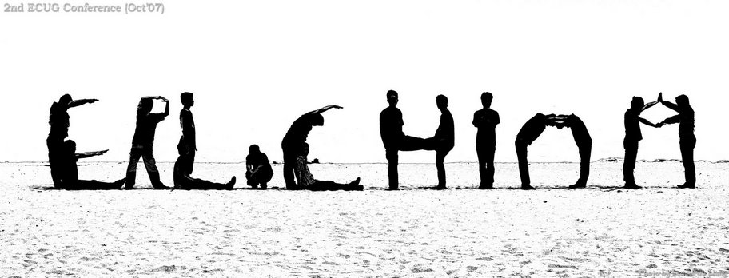

ECUG II

## sociallearnlab.org

> 教育大发现 2008 ~ 2010

社区顾问

## TechParty.org

> 珠三角技术沙龙 2009 ~

ZPUG 太小

## PyCon Asia Pacific

> [PythoniCamp](https://wiki.woodpecker.org.cn/moin/PyCon2010)

2010 新加坡

## 2011

> PyConChina

不忿

## PyCon中国

> 2012 ~

自己的 conference

## GDG 珠海

> 2013 ~

Google+

## 2014

> 读易洞

线下读书会…

## OMOOC.py

> 2015~18

有偿

## 自怼圈

> 170401 ~

知识付费

## 101.camp

> 181225 ~

服务大众

自筑社群

## TFUG 珠海

> 190214 ~

AI 落地

# 好事

## 开发

> 本分
- 3D 动画
- 职业顿悟
- …

## 管理

> 过程改进

用技术改善技术人生活品质

## 写作

> 爱好

22CC

[figure not shown]

2009

[figure not shown]

2013

[figure not shown]

输出是更残酷的输入

## 社区

> 感召
- 参与
- 理解
- 服务
- 发起
- 策划
- …

## 社群

> 社区群落 ~> 私域流量
- 有关联
- 场景向
- 自运营
- …

## 自怼

> DebugUself

有心无心,自然聚焦

[figure not shown]

the force…

# 莫问

## 35

> 门槛值

## 高龄

> 程序猿的自救

> > 45

## 常见

> 方向…

## 专家

> 天下第一

## 管理

> 产品/开发/…

## 创业

> 十死无生

## 投资

> 看起来很美

钱生钱

## 咨询

> 天下第几?

## 培训?

> 挂靠/教师证/…

## 转行

> 农业/餐饮/…

## 蛰伏

> 家领导给力…

## 恩格尔系数

> Engel’s Coefficient

居民家庭中食物支出占消费总支出的比重

## 自救系数

> SelfRescue’s Coefficient

被动收入占总收入的比重

## 被动收入比

> 睡后收入 ;-)
- `< 0.1 苦力`
- `< 0.4 超市自由`
- `< 0.8 职业自由`
- `> 1.0 人生自由`

## 差异

> 核心区别
- 职业…
- 脱产…

## 商品

> 构成
- 自己的…
  - 时间/精力/经验/…
- 作品的…
  - 品质/思想/价值/…

## 눈_눈

> 提醒

[figure not shown]

Zzz…

# 前程

## 目标

> 超市自由

> > 睡后收入++

## 流量

> 莫愁前路无知己

> 天下谁人不识君

## 企业

> 传统流量

## 定投…

> 流量资金

## 文创

> 娱乐流量

## 技术?

> 自动流量

[figure not shown]

靠谱

## 靠谱

> Kaopulity
- **K**eep
- **a**ll
- **o**f
- **p**rocesses
- **u**sabi**lity**

## 纷繁

> 可用不难

> > 难在同时

## 私域流量

> 从何而来?
- 长期坚持
- 品质保证
- 信赖累积

## 养望

> 名声可养

## 宅

> [OTAKU](http://zh.wikipedia.org/wiki/%E5%BE%A1%E5%AE%85%E6%97%8F)

复合魂器 ;-)

## 玩

> 也得认真
- 成功只是成功人士的习惯…

## 渐进

> 10年不多

现在开始

## 蟒营™

> 101.camp

不仅因为一个好域名…

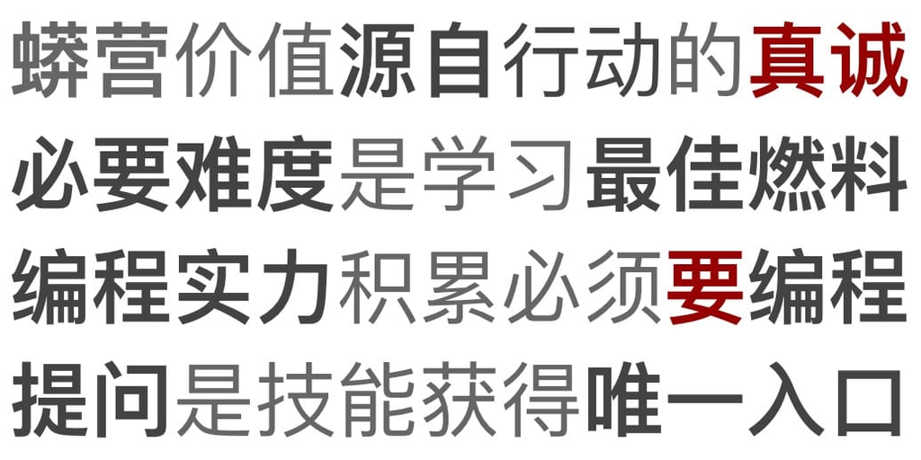

嗯哼

## 自毁倾向

> [NC0:一个自毁倾向社区的形成](https://blog.101.camp/NC/190711-NC101-self-destruction/)

> > 190711 Linux中国

## 学习->学习

> 正义自学

2002…开始下意识积累…

## 探索17年

> 181225 蟒营™Python 入门班

> > [101.camp](https://101.camp/)

## 开始

> 困难才能变成问题

[figure not shown]

logging now

## Aristotle

> “For the things we have to learn before we can do them, we learn by doing them.”

## 亚里士多德

> “我们通过做来学习

> 我们必须学习去做的…”

~ 伦理学

## 意识

> 要去作什么…

比能作什么重要

[figure not shown]

askdama@googlegroups.com

# (￣▽￣)

## 눈_눈

> 提醒

[figure not shown]

logging now

## 内省

> 不忘初心…
- 什么是企业?
- 什么是产品?
- …

[figure not shown]

DM11: 终于开始回忆

[Blogging 蟒营™ 博客](https://blog.101.camp/DM/191022-pycon19nn/)

```
https://blog.101.camp/DM/191022-pycon19nn/
```

> askdama@googlegroups.com

## 幻灯

> NOT PPT

[slides.101.camp/pycon19nn](http://slides.101.camp/pycon19nn.html)

## 是也乎

- 191026 speech
  - 1010 appended …
  - 2242 fixed
- 191020 pub
- 191001 重构
- 190910 re-init.
- 190801 init.

[figure not shown]

PyCon19中国.南宁

[figure not shown]

101.camp